# Encontro dos Saberes PARNA do Jaú (2022)

Análise mamíferos terrestres – 2015 a 2021

Elildo Carvalho Jr - ICMBio/CENAP

2022-04-19

## Apresentação

Este relatório apresenta resultados do Programa Monitora, Subprograma Terrestre, Componente Florestal Global, Alvo Mamíferos terrestres de médio e grande porte, protocolo básico, na **Parque Nacional do Jaú**, 2015 a 2021. O principal objetivo é subsidiar o Encontro dos Saberes que será realizado nesta unidade.

## Métodos

O protocolo básico para mamíferos utiliza o método de transecções lineares. Resumidamente, dois observadores percorrem as transecções a uma velocidade constante e registram, para cada avistamento de animais dos grupos-alvo, a espécie, o número de indivíduos e a distância perperndicular entre o primeiro indivíduo avistado e o centro da trilha. Cada UC deve ter pelo menos três transectos de 5 km e o esforço anual mínimo, combinando todos os transectos, deve ser de 150 km percorridos. A tabela 1 apresenta o esforço anual por trilha na PARNA do jau.

Tabela 1. Esforço de amostragem anual (em km) nas trilhas do ProgramaMonitora na PARNA do Jaú, 2015-2021

| EA | nome EA | 2015 | 2016 | 2017 | 2018 | 2019 | 2020 | 2021 |
| --- | --- | --- | --- | --- | --- | --- | --- | --- |
| 1 | Volta | 50 | 55 | 35 | 50 | 40 | NA | 50 |
| 2 | Cachoeira | 45 | 50 | 50 | 40 | 50 | NA | 50 |
| 3 | Tiaraca | 50 | 45 | 45 | 45 | 50 | NA | 50 |

## Número total de encontros

A tabela 2 apresenta o número total de encontros e de indivíduos avistados por espécie. As espécies mais encontradas foram, nessa ordem: macaco-prego, quatipuru, cutiara, macaco-velho e cutia. A maioria das outras espécies foram encontradas poucas (< 10) vezes. Para as espécies que vivem em grupos, o número indivíduos pode ser maior do que o número de encontros.

É importante lembrar que só porque uma espécie foi registrada poucas vezes, não quer dizer necessariamente que ela seja rara. Por exemplo, o protocolo não funciona bem para espécies noturnas como as antas e as pacas, pois as trilhas são percorridas durante o dia, quando essas espécies estão menos ativas. Além disso, espécies que são caçadas podem ficar muito ariscas, fugindo ao menor sinal da aproximação de pessoas.

Tabela 2. Numero de registros por especie obtidos pelo protocolo básicodo Programa Monitora na PARNA do Jaú, 2015-2021

| Ordem | Familia | Especie | Nome popular | Encontros | Individuos |
| --- | --- | --- | --- | --- | --- |
| Artiodactyla | Cervidae | Mazama americana | Veado-mateiro | 5 | 5 |
| Artiodactyla | Cervidae | Mazama nemorivaga | Veado-fuboca | 6 | 6 |
| Artiodactyla | Tayassuidae | Pecari tajacu | Caititu | 13 | 61 |
| Artiodactyla | Tayassuidae | Tayassu pecari | Queixada | 2 | 31 |
| Carnivora | Felidae | Leopardus pardalis | Jaguatirica | 1 | 1 |
| Carnivora | Felidae | Leopardus tigrinus | Gato-do-mato | 1 | 1 |
| Carnivora | Felidae | Puma concolor | Onça-vermelha | 2 | 2 |
| Carnivora | Mustelidae | Eira barbara | Irara | 5 | 6 |
| Carnivora | Mustelidae | Lontra longicaudis | Lontra | 3 | 4 |
| Carnivora | Mustelidae | Pteronura brasiliensis | Ariranha | 4 | 11 |
| Pilosa | Megalonychidae | Choloepus didactylus | Preguiça-real | 2 | 2 |
| Pilosa | Myrmecophagidae | Tamandua tetradactyla | Mambira | 2 | 2 |
| Primates | Atelidae | Alouatta juara | Guariba | 1 | 2 |
| Primates | Cebidae | Cebus albifrons | Cairara | 10 | 56 |
| Primates | Cebidae | Saimiri cassiquiarensis | Mico-de-cheiro | 6 | 51 |
| Primates | Cebidae | Sapajus apella | Macaco-prego | 108 | 550 |
| Primates | Pitheciidae | Cacajao melanocephalus | Uacarí-preto | 7 | 36 |
| Primates | Pitheciidae | Pithecia pithecia | Macaco-velho | 38 | 133 |
| Rodentia | Dasyproctidae | Dasyprocta fuliginosa | Cutia | 35 | 38 |
| Rodentia | Dasyproctidae | Myoprocta pratti | Cutiara | 84 | 85 |
| Rodentia | Sciuridae | Sciuridae | Quatipuru | 95 | 110 |

Figura 1. Número total de encontros por espécie na PARNA do Jaú, 2015-2021. Somente espécies com mais de 5 encontros foram incluídas

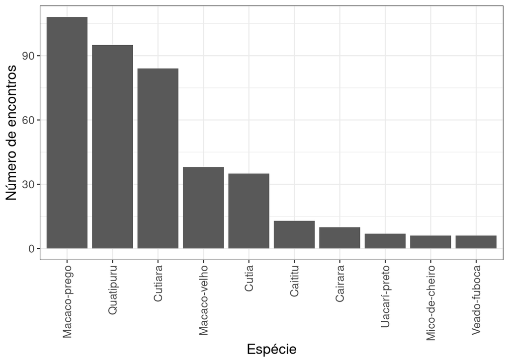

# Tendências populacionais

Somente cinco espécies apresentaram taxa de encontro anual média > 0.04 ind/km, o que equivale aproximadamente a um encontro a cada 25 km percorridos (Tabela 3): macaco-prego, quatipuru (três espécies agrupadas), cutiara, macaco-velho e cutia. As Figuras 2 a 5 mostram como as taxas de avistamento variaram para estas espécies ao longo do monitoramento.

As outras especies não tiveram número de encontros suficiente para permitir uma análise de suas tendências populacionais.

Tabela 3. Taxas de encontro anuais no PARNA do Jaú

| especie | 2015 | 2016 | 2017 | 2018 | 2019 | 2020 | 2021 | média |
| --- | --- | --- | --- | --- | --- | --- | --- | --- |
| Sapajus apella | 0.10 | 0.13 | 0.20 | 0.06 | 0.14 | NA | 0.13 | 0.13 |
| Sciuridae | 0.08 | 0.10 | 0.08 | 0.16 | 0.11 | NA | 0.14 | 0.11 |
| Myoprocta pratti | 0.09 | 0.07 | 0.07 | 0.10 | 0.14 | NA | 0.12 | 0.10 |
| Pithecia pithecia | 0.06 | 0.05 | 0.02 | 0.04 | 0.05 | NA | 0.05 | 0.04 |
| Dasyprocta fuliginosa | 0.03 | 0.01 | 0.03 | 0.02 | 0.03 | NA | 0.11 | 0.04 |

Figura 2. Taxa de encontro anual para macaco-prego na PARNA do Jaú, 2015-2021

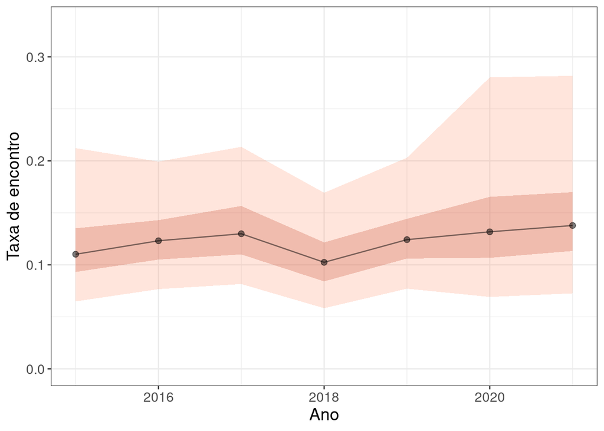

Figura 3. Taxa de encontro anual para macaco-velho na PARNA do Jaú, 2015-2021

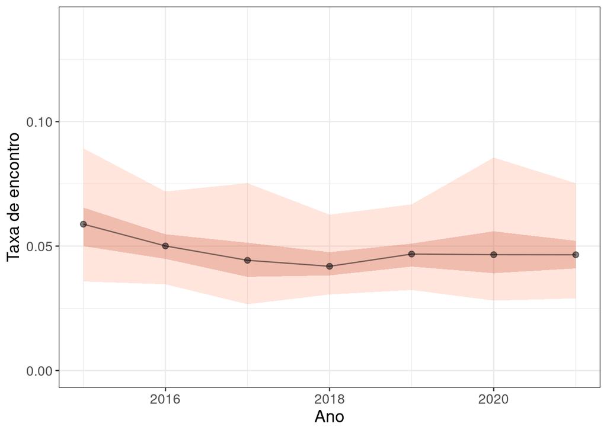

Figura 4. Taxa de encontro anual para cutia na PARNA do Jaú, 2015-2021

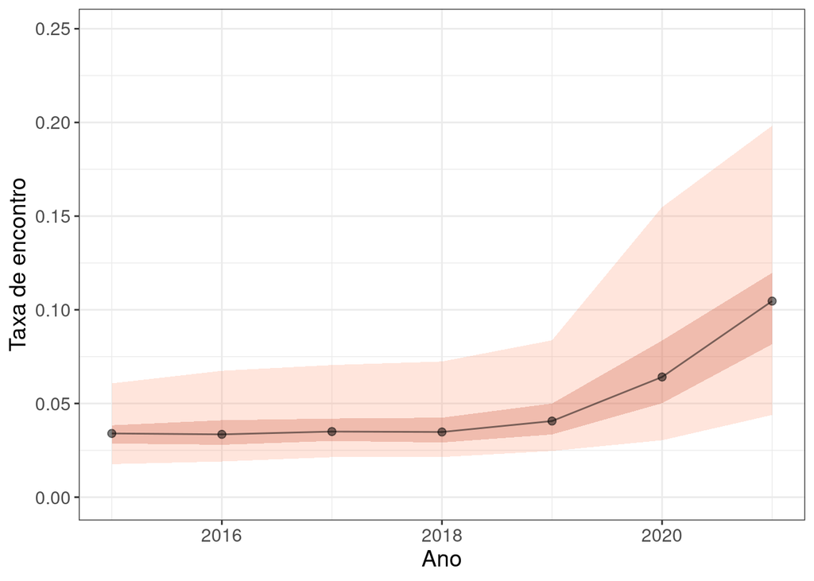

Figura 5. Taxa de encontro anual para cutiara na PARNA do Jaú, 2015-2021

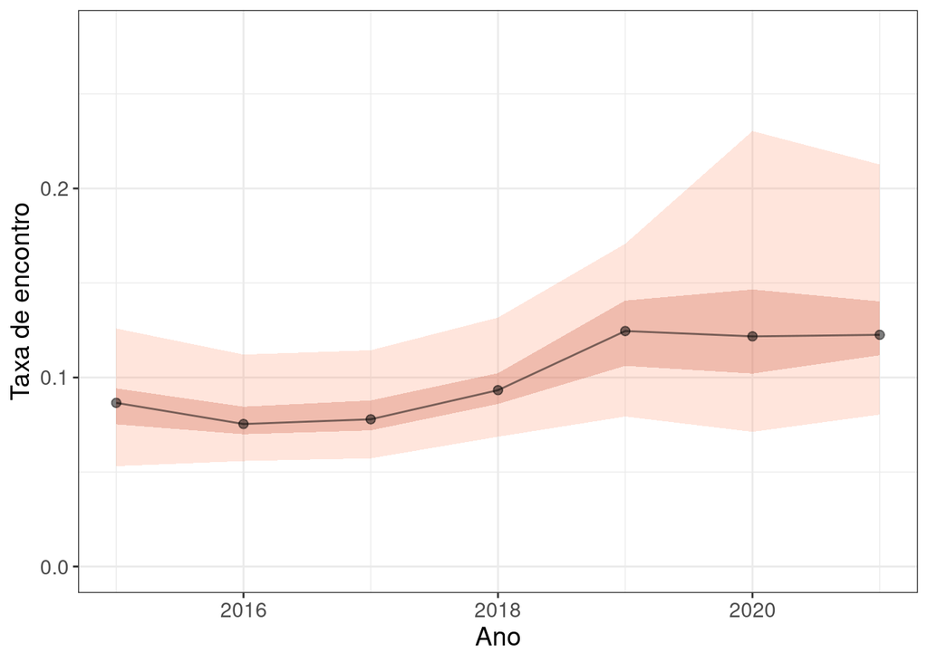

# Tendências populacionais por trilha

Figura 7. Taxa de encontro anual para macaco-prego por trilha na PARNA do Jaú, 2015-2021

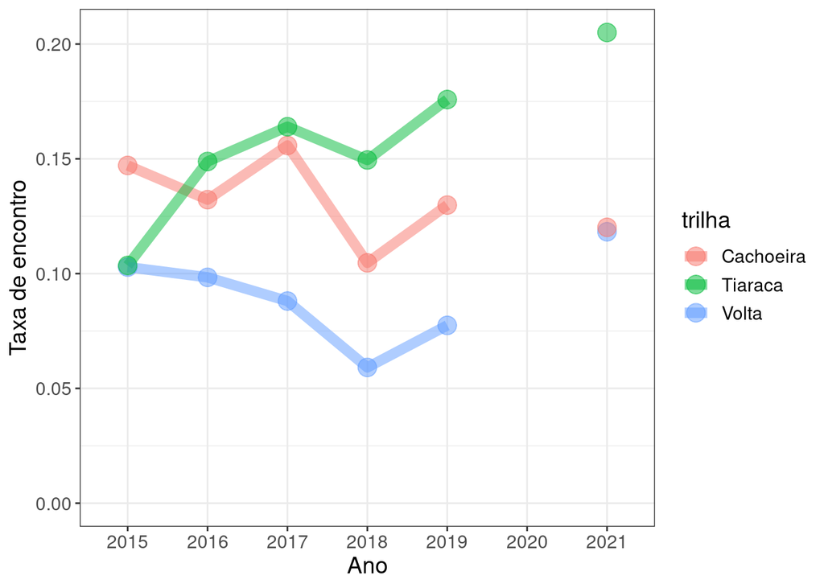

Figura 8. Taxa de encontro anual para macaco-velho por trilha na PARNA do Jaú, 2015-2021

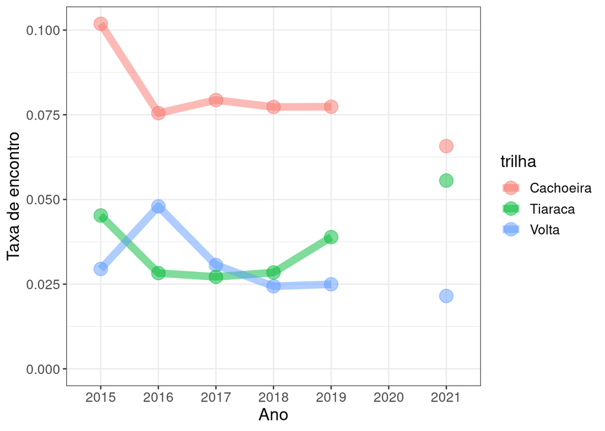

Figura 9. Taxa de encontro anual para cutia por trilha na PARNA do Jaú, 2015-2021

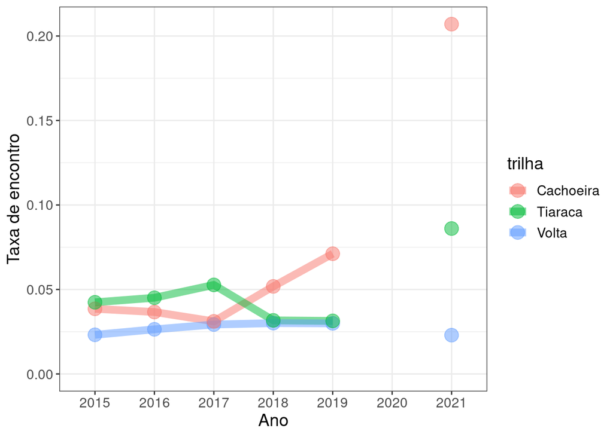

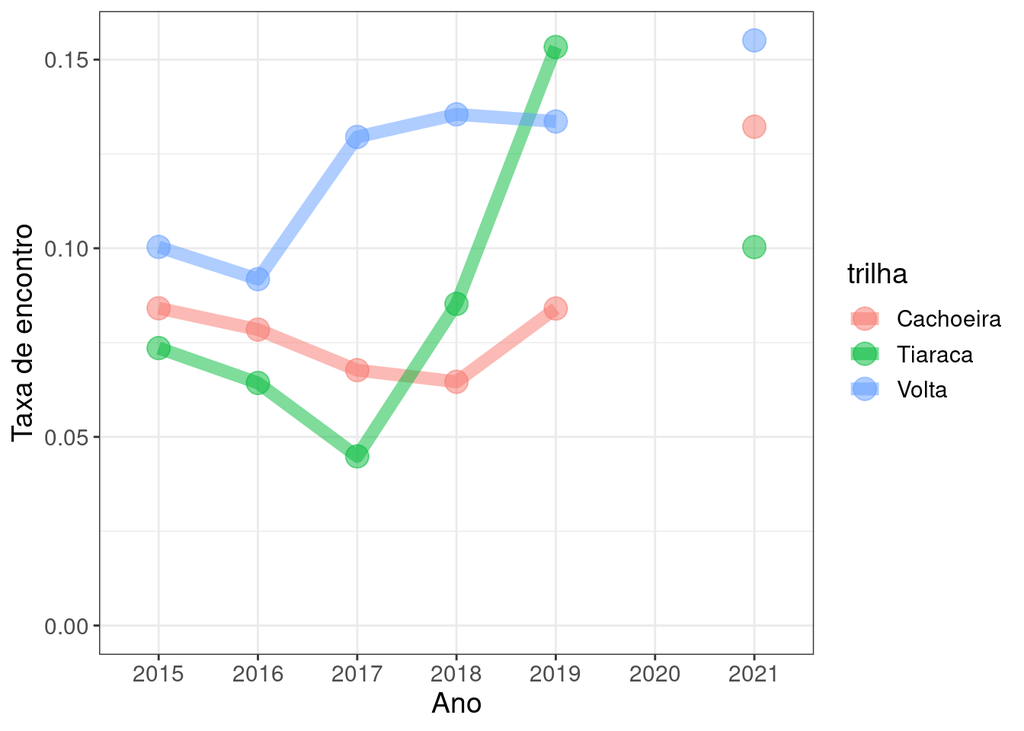

# Perguntas e reflexões

As espécies mais comuns encontradas no monitoramento foram macaco-prego, quatipuru, cutiara, macaco-velho e cutia. Isso está de acordo com a percepção da comunidade?

Como explicar as variações na taxa de avistamento de macacos-prego?

Como explicar as variações na taxa de avistamento entre as trilhas?

Porque é importante monitorar várias trilhas ao invés de apenas uma?